# index

```
Training model for index: 000001.SS
Epoch [10/50], Loss: 0.7147007584571838
Epoch [20/50], Loss: 0.7019016146659851
Epoch [30/50], Loss: 0.6954967379570007
Epoch [40/50], Loss: 0.6933860182762146
Epoch [50/50], Loss: 0.6931155920028687
Accuracy for index 000001.SS: 0.5483028720626631

              precision    recall  f1-score   support

         0.0       0.00      0.00      0.00       519
         1.0       0.55      1.00      0.71       630

    accuracy                           0.55      1149
   macro avg       0.27      0.50      0.35      1149
weighted avg       0.30      0.55      0.39      1149
```

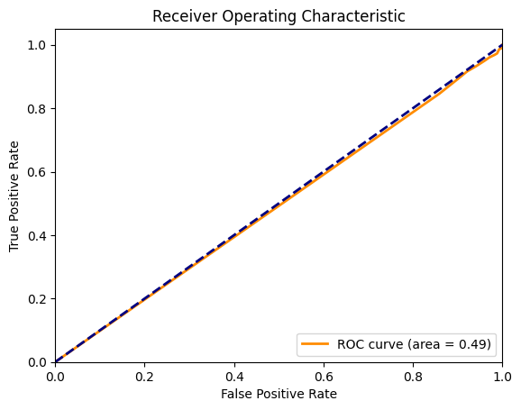

```
Training model for index: 399001.SZ
Epoch [10/50], Loss: 0.6929795742034912
Epoch [20/50], Loss: 0.693135142326355
Epoch [30/50], Loss: 0.6930074095726013
Epoch [40/50], Loss: 0.6929861903190613
Epoch [50/50], Loss: 0.6929852366447449
Accuracy for index 399001.SZ: 0.5253940455341506

              precision    recall  f1-score   support

         0.0       0.00      0.00      0.00       542
         1.0       0.53      1.00      0.69       600

    accuracy                           0.53      1142
   macro avg       0.26      0.50      0.34      1142
weighted avg       0.28      0.53      0.36      1142
```

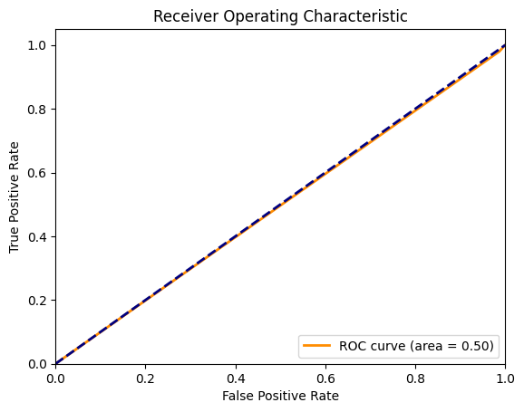

```
Training model for index: GDAXI
Epoch [10/50], Loss: 0.6917820572853088
Epoch [20/50], Loss: 0.6914430260658264
Epoch [30/50], Loss: 0.6914891600608826
Epoch [40/50], Loss: 0.691450834274292
Epoch [50/50], Loss: 0.691437840461731
Accuracy for index GDAXI: 0.5423122765196663

              precision    recall  f1-score   support

         0.0       0.00      0.00      0.00       768
         1.0       0.54      1.00      0.70       910

    accuracy                           0.54      1678
   macro avg       0.27      0.50      0.35      1678
weighted avg       0.29      0.54      0.38      1678
```

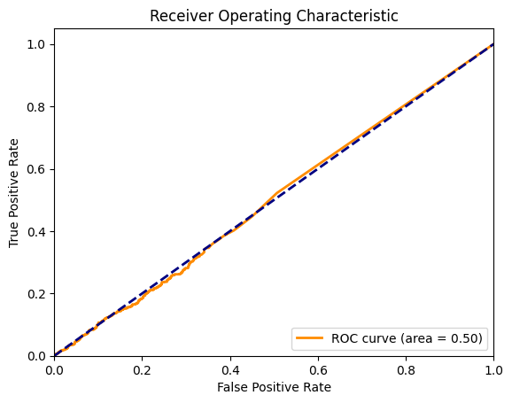

```
Training model for index: GSPTSE
Epoch [10/50], Loss: 0.6910378932952881
Epoch [20/50], Loss: 0.6914597153663635
Epoch [30/50], Loss: 0.6909634470939636
Epoch [40/50], Loss: 0.6908484697341919
Epoch [50/50], Loss: 0.6908339262008667
Accuracy for index GSPTSE: 0.5329198473282443

              precision    recall  f1-score   support

         0.0       0.00      0.00      0.00       979
         1.0       0.53      1.00      0.70      1117

    accuracy                           0.53      2096
   macro avg       0.27      0.50      0.35      2096
weighted avg       0.28      0.53      0.37      2096
```

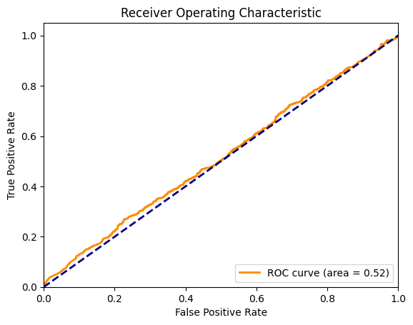

```
Training model for index: HSI
Epoch [10/50], Loss: 0.695560097694397
Epoch [20/50], Loss: 0.6923528909683228
Epoch [30/50], Loss: 0.692284345626831
Epoch [40/50], Loss: 0.6923341751098633
Epoch [50/50], Loss: 0.6921844482421875
Accuracy for index HSI: 0.5210183540556542

              precision    recall  f1-score   support

         0.0       0.00      0.00      0.00       809
         1.0       0.52      1.00      0.69       880

    accuracy                           0.52      1689
   macro avg       0.26      0.50      0.34      1689
weighted avg       0.27      0.52      0.36      1689
```

```
Training model for index: IXIC
Epoch [10/50], Loss: 0.6876658797264099
Epoch [20/50], Loss: 0.6861298084259033
Epoch [30/50], Loss: 0.6861093044281006
Epoch [40/50], Loss: 0.6858646273612976
Epoch [50/50], Loss: 0.6857823133468628
Accuracy for index IXIC: 0.5549841772151899

              precision    recall  f1-score   support

         0.0       0.00      0.00      0.00      1125
         1.0       0.55      1.00      0.71      1403

    accuracy                           0.55      2528
   macro avg       0.28      0.50      0.36      2528
weighted avg       0.31      0.55      0.40      2528
```

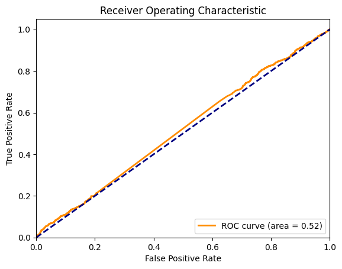

```
Training model for index: J203.JO
Epoch [10/50], Loss: 0.7127707004547119
Epoch [20/50], Loss: 0.7021265029907227
Epoch [30/50], Loss: 0.6958627700805664
Epoch [40/50], Loss: 0.692953884601593
Epoch [50/50], Loss: 0.6919993162155151
Accuracy for index J203.JO: 0.5065217391304347

              precision    recall  f1-score   support

         0.0       0.00      0.00      0.00       227
         1.0       0.51      1.00      0.67       233

    accuracy                           0.51       460
   macro avg       0.25      0.50      0.34       460
weighted avg       0.26      0.51      0.34       460
```

```
Training model for index: N100
Epoch [10/50], Loss: 0.6952286958694458
Epoch [20/50], Loss: 0.6917523741722107
Epoch [30/50], Loss: 0.6914201974868774
Epoch [40/50], Loss: 0.6914260983467102
Epoch [50/50], Loss: 0.6914215683937073
Accuracy for index N100: 0.5373271889400921

              precision    recall  f1-score   support

         0.0       0.00      0.00      0.00       502
         1.0       0.54      1.00      0.70       583

    accuracy                           0.54      1085
   macro avg       0.27      0.50      0.35      1085
weighted avg       0.29      0.54      0.38      1085
```

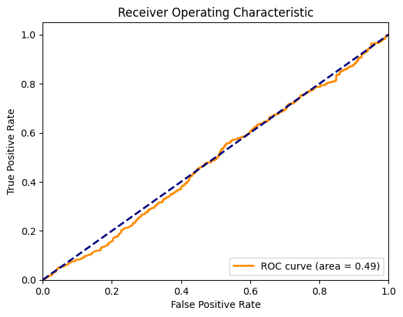

```
Training model for index: N225
Epoch [10/50], Loss: 0.6953410506248474
Epoch [20/50], Loss: 0.6923894286155701
Epoch [30/50], Loss: 0.6924887895584106
Epoch [40/50], Loss: 0.6924496293067932
Epoch [50/50], Loss: 0.6923536658287048
Accuracy for index N225: 0.5095840867992767

              precision    recall  f1-score   support

         0.0       0.00      0.00      0.00      1356
         1.0       0.51      1.00      0.68      1409

    accuracy                           0.51      2765
   macro avg       0.25      0.50      0.34      2765
weighted avg       0.26      0.51      0.34      2765
```

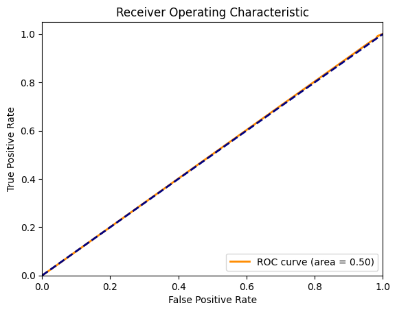

```
Training model for index: NSEI
Epoch [10/50], Loss: 0.6914418339729309
Epoch [20/50], Loss: 0.690971851348877
Epoch [30/50], Loss: 0.6910540461540222
Epoch [40/50], Loss: 0.6909844279289246
Epoch [50/50], Loss: 0.6909696459770203
Accuracy for index NSEI: 0.5106060606060606

              precision    recall  f1-score   support

         0.0       0.00      0.00      0.00       323
         1.0       0.51      1.00      0.68       337

    accuracy                           0.51       660
   macro avg       0.26      0.50      0.34       660
weighted avg       0.26      0.51      0.35       660
```

```
Training model for index: NYA
Epoch [10/50], Loss: 0.7026234269142151
Epoch [20/50], Loss: 0.692080557346344
Epoch [30/50], Loss: 0.6912011504173279
Epoch [40/50], Loss: 0.6912034153938293
Epoch [50/50], Loss: 0.6909947991371155
Accuracy for index NYA: 0.5158273381294964

              precision    recall  f1-score   support

         0.0       0.00      0.00      0.00      1346
         1.0       0.52      1.00      0.68      1434

    accuracy                           0.52      2780
   macro avg       0.26      0.50      0.34      2780
weighted avg       0.27      0.52      0.35      2780
```

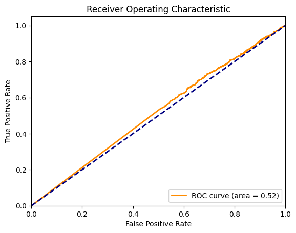

```
Training model for index: SSMI
Epoch [10/50], Loss: 0.6904928088188171
Epoch [20/50], Loss: 0.6901043057441711
Epoch [30/50], Loss: 0.6904226541519165
Epoch [40/50], Loss: 0.6902495622634888
Epoch [50/50], Loss: 0.6902639865875244
Accuracy for index SSMI: 0.5429508196721311

              precision    recall  f1-score   support

         0.0       0.00      0.00      0.00       697
         1.0       0.54      1.00      0.70       828

    accuracy                           0.54      1525
   macro avg       0.27      0.50      0.35      1525
weighted avg       0.29      0.54      0.38      1525
```

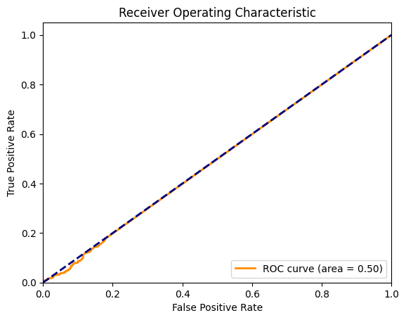

```
Training model for index: TWII
Epoch [10/50], Loss: 0.6907640099525452
Epoch [20/50], Loss: 0.6908307671546936
Epoch [30/50], Loss: 0.6907439231872559
Epoch [40/50], Loss: 0.6907505393028259
Epoch [50/50], Loss: 0.6907381415367126
Accuracy for index TWII: 0.5481099656357389

              precision    recall  f1-score   support

         0.0       0.00      0.00      0.00       526
         1.0       0.55      1.00      0.71       638

    accuracy                           0.55      1164
   macro avg       0.27      0.50      0.35      1164
weighted avg       0.30      0.55      0.39      1164
```

```python
import numpy as np
import torch
import torch.nn as nn
from sklearn.model_selection import train_test_split
from sklearn.metrics import accuracy_score
import warnings
warnings.filterwarnings("ignore")

# Set random seed for reproducibility
torch.manual_seed(42)

# Prepare the data
def create_dataset(data, look_back=1):
    X, y = [], []
    for i in range(len(data) - look_back):
        X.append(data[i:(i + look_back), 0])
        y.append(1 if data[i + look_back, 0] > data[i + look_back - 1, 0] else 0)
    return np.array(X), np.array(y)

# Define the LSTM model
class LSTMModel(nn.Module):
    def __init__(self, input_size, hidden_size, num_layers, output_size):
        super(LSTMModel, self).__init__()
        self.hidden_size = hidden_size
        self.num_layers = num_layers
        self.lstm = nn.LSTM(input_size, hidden_size, num_layers, batch_first=True)
        self.fc = nn.Linear(hidden_size, output_size)
        self.sigmoid = nn.Sigmoid()

    def forward(self, x):
        h0 = torch.zeros(self.num_layers, x.size(0), self.hidden_size).to(device)
        c0 = torch.zeros(self.num_layers, x.size(0), self.hidden_size).to(device)
        out, _ = self.lstm(x, (h0, c0))
        out = self.fc(out[:, -1, :])
        out = self.sigmoid(out)
        return out

# Set device (GPU if available, else CPU)
device = torch.device('cuda' if torch.cuda.is_available() else 'cpu')

# Get a list of all the indices
indices = data['Index'].unique()

# Set the look_back value and other model parameters
look_back = 50
input_size = 1
hidden_size = 50
num_layers = 1
output_size = 1
# lower epochs make the model faster but less accurate
num_epochs = 50
batch_size = 32
learning_rate = 0.001

# Loop through all the indices
for index in indices:
    print(f"Training model for index: {index}")

    # Extract the corresponding data
    data_index = data[data['Index'] == index]['Open'].values.reshape(-1, 1)

    # Create the dataset
    X, y = create_dataset(data_index, look_back)

    # Split the data into training and testing sets
    X_train, X_test, y_train, y_test = train_test_split(X, y, test_size=0.2, random_state=42)

    # Convert data to PyTorch tensors
    X_train = torch.tensor(X_train, dtype=torch.float32).to(device)
    y_train = torch.tensor(y_train, dtype=torch.float32).to(device)
    X_test = torch.tensor(X_test, dtype=torch.float32).to(device)
    y_test = torch.tensor(y_test, dtype=torch.float32).to(device)

    # Reshape the input tensors to have dimensions (batch_size, sequence_length, input_size)
    X_train = X_train.reshape(X_train.shape[0], look_back, input_size)
    X_test = X_test.reshape(X_test.shape[0], look_back, input_size)

    # Create the LSTM model
    model = LSTMModel(input_size, hidden_size, num_layers, output_size).to(device)

    # Define the loss function and optimizer
    criterion = nn.BCELoss()
    optimizer = torch.optim.Adam(model.parameters(), lr=learning_rate)

    # Train the model
    for epoch in range(num_epochs):
        # Forward pass
        outputs = model(X_train)
        loss = criterion(outputs, y_train.view(-1, 1))

        # Backward pass and optimization
        optimizer.zero_grad()
        loss.backward()
        optimizer.step()

        if (epoch + 1) % 10 == 0:
            print(f"Epoch [{epoch + 1}/{num_epochs}], Loss: {loss.item()}")

    # Make predictions on the test set
    with torch.no_grad():
        y_pred = model(X_test)
        y_pred_class = (y_pred > 0.5).float()

    # Calculate the accuracy of the model
    accuracy = accuracy_score(y_test.cpu().numpy(), y_pred_class.cpu().numpy())
    print(f"Accuracy for index {index}: {accuracy}\n")

    # precision, recall, f1-score
    from sklearn.metrics import classification_report
    print(classification_report(y_test.cpu().numpy(), y_pred_class.cpu().numpy()))

    # roc curve helps show the performance vs no skill for boolean classification
    from sklearn.metrics import roc_curve, auc
    fpr, tpr, _ = roc_curve(y_test.cpu().numpy(), y_pred.cpu().numpy())
    roc_auc = auc(fpr, tpr)

    plt.figure()
    lw = 2
    plt.plot(fpr, tpr, color='darkorange', lw=lw, label='ROC curve (area = %0.2f)' % roc_auc)
    plt.plot([0, 1], [0, 1], color='navy', lw=lw, linestyle='--')
    plt.xlim([0.0, 1.0])
    plt.ylim([0.0, 1.05])
    plt.xlabel('False Positive Rate')
    plt.ylabel('True Positive Rate')
    plt.title('Receiver Operating Characteristic')
    plt.legend(loc="lower right")
    plt.show()
```

The performance of that model is ok at best since it seems to be performing at a boolean guess level (50%) with minor variance. Let us try and augment this code by using k-fold cross validation and see if it helps make the model perform better.

```
Training model for index: 000001.SS
Fold 1/5
Epoch [10/50], Loss: 0.6987060904502869
Epoch [20/50], Loss: 0.693169891834259
Epoch [30/50], Loss: 0.6940085291862488
Epoch [40/50], Loss: 0.6934655904769897
Epoch [50/50], Loss: 0.6931219100952148
Accuracy for fold 1: 0.5483028720626631

Fold 2/5
Epoch [10/50], Loss: 0.6926479935646057
Epoch [20/50], Loss: 0.6926019787788391
Epoch [30/50], Loss: 0.692577064037323
Epoch [40/50], Loss: 0.6925610303878784
Epoch [50/50], Loss: 0.6925442218780518
Accuracy for fold 2: 0.5017421602787456

Fold 3/5
Epoch [10/50], Loss: 0.6930274963378906
Epoch [20/50], Loss: 0.6932772994041443
Epoch [30/50], Loss: 0.6928587555885315
Epoch [40/50], Loss: 0.6929070949554443
Epoch [50/50], Loss: 0.6928570866584778
Accuracy for fold 3: 0.5165505226480837

Fold 4/5
Epoch [10/50], Loss: 0.6926948428153992
Epoch [20/50], Loss: 0.6926579475402832
Epoch [30/50], Loss: 0.6925753951072693
Epoch [40/50], Loss: 0.6925414204597473
Epoch [50/50], Loss: 0.6925471425056458
Accuracy for fold 4: 0.4965156794425087

Fold 5/5
Epoch [10/50], Loss: 0.6927990317344666
Epoch [20/50], Loss: 0.6927068829536438
Epoch [30/50], Loss: 0.692656934261322
Epoch [40/50], Loss: 0.6926578283309937
Epoch [50/50], Loss: 0.6926490068435669
Accuracy for fold 5: 0.5017421602787456
```

[output cut: 41 more lines]

```

    accuracy                           0.50      1148
   macro avg       0.25      0.50      0.33      1148
weighted avg       0.25      0.50      0.33      1148


Classification report for fold 5:
              precision    recall  f1-score   support

         0.0       0.00      0.00      0.00       572
         1.0       0.50      1.00      0.67       576

    accuracy                           0.50      1148
   macro avg       0.25      0.50      0.33      1148
weighted avg       0.25      0.50      0.34      1148
```

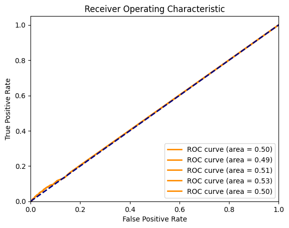

```python
from sklearn.model_selection import KFold
import warnings
warnings.filterwarnings("ignore")

num_folds = 5

# Loop through all the indices
for index in indices:
    print(f"Training model for index: {index}")

    # Extract the corresponding data
    data_index = data[data['Index'] == index]['Open'].values.reshape(-1, 1)

    # Create the dataset
    X, y = create_dataset(data_index, look_back)

    # Convert data to PyTorch tensors
    X = torch.tensor(X, dtype=torch.float32).to(device)
    y = torch.tensor(y, dtype=torch.float32).to(device)

    # Reshape the input tensors to have dimensions (batch_size, sequence_length, input_size)
    X = X.reshape(X.shape[0], look_back, input_size)

    # Create k-fold cross-validation splits
    kfold = KFold(n_splits=num_folds, shuffle=True, random_state=42)

    fold_accuracies = []
    fold_reports = []
    roc_auc_funcs = []

    for fold, (train_idx, test_idx) in enumerate(kfold.split(X)):
        print(f"Fold {fold + 1}/{num_folds}")

        # Split the data into training and testing sets for the current fold
        X_train, X_test = X[train_idx], X[test_idx]
        y_train, y_test = y[train_idx], y[test_idx]

        # Create the LSTM model
        model = LSTMModel(input_size, hidden_size, num_layers, output_size).to(device)

        # Define the loss function and optimizer
        criterion = nn.BCELoss()
        optimizer = torch.optim.Adam(model.parameters(), lr=learning_rate)

        # Train the model
        for epoch in range(num_epochs):
            # Forward pass
            outputs = model(X_train)
            loss = criterion(outputs, y_train.view(-1, 1))

            # Backward pass and optimization
            optimizer.zero_grad()
            loss.backward()
            optimizer.step()

            if (epoch + 1) % 10 == 0:
                print(f"Epoch [{epoch + 1}/{num_epochs}], Loss: {loss.item()}")

        # Make predictions on the test set
        with torch.no_grad():
            y_pred = model(X_test)
            y_pred_class = (y_pred > 0.5).float()

        # Calculate the accuracy and classification report for the current fold
        accuracy = accuracy_score(y_test.cpu().numpy(), y_pred_class.cpu().numpy())
        report = classification_report(y_test.cpu().numpy(), y_pred_class.cpu().numpy())

        fold_accuracies.append(accuracy)
        fold_reports.append(report)

        print(f"Accuracy for fold {fold + 1}: {accuracy}\n")

        from sklearn.metrics import roc_curve, auc
        fpr, tpr, _ = roc_curve(y_test.cpu().numpy(), y_pred.cpu().numpy())
        roc_auc = auc(fpr, tpr)

        roc_auc_funcs.append(roc_auc)

    # Calculate the mean accuracy across all folds
    mean_accuracy = np.mean(fold_accuracies)
    print(f"Mean accuracy for index {index}: {mean_accuracy}\n")

    # Print the classification report for each fold
    for fold, report in enumerate(fold_reports, 1):
        print(f"Classification report for fold {fold}:\n{report}\n")

    # roc curves of all folds helps show the performance vs no skill for boolean classification
    plt.figure()
    lw = 2
    for i in range(num_folds):
        plt.plot(fpr, tpr, color='darkorange', lw=lw, label='ROC curve (area = %0.2f)' % roc_auc_funcs[i])
    plt.plot([0, 1], [0, 1], color='navy', lw=lw, linestyle='--')
    plt.xlim([0.0, 1.0])
    plt.ylim([0.0, 1.05])
    plt.xlabel('False Positive Rate')
    plt.ylabel('True Positive Rate')
    plt.title('Receiver Operating Characteristic')
    plt.legend(loc="lower right")
    plt.show()

    break
```

The k-fold cross validation seemed to have no effect if not an extremely minor one on the accruacy of the model. Lets try and make it better using L2 regularization to improve the model's generalization ability (ridge).

```
Training model for index: 000001.SS
Epoch [10/50], Loss: 0.7279390096664429
Epoch [20/50], Loss: 0.7104291915893555
Epoch [30/50], Loss: 0.7032250165939331
Epoch [40/50], Loss: 0.7023653984069824
Epoch [50/50], Loss: 0.701522946357727
Accuracy for index 000001.SS: 0.5056570931244561

Classification report for index 000001.SS:
              precision    recall  f1-score   support

         0.0       0.44      0.37      0.40       519
         1.0       0.54      0.62      0.58       630

    accuracy                           0.51      1149
   macro avg       0.49      0.49      0.49      1149
weighted avg       0.50      0.51      0.50      1149
```

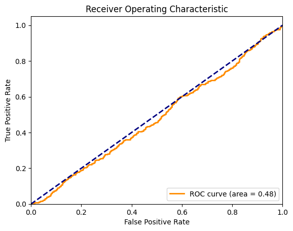

```python
import numpy as np
import torch
import torch.nn as nn
from sklearn.model_selection import train_test_split
from sklearn.metrics import accuracy_score, classification_report

# Set random seed for reproducibility
torch.manual_seed(42)

# Prepare the data
def create_dataset(data, look_back=1):
    X, y = [], []
    for i in range(len(data) - look_back):
        X.append(data[i:(i + look_back), 0])
        y.append(1 if data[i + look_back, 0] > data[i + look_back - 1, 0] else 0)
    return np.array(X), np.array(y)

# Define the LSTM model
class LSTMModel(nn.Module):
    def __init__(self, input_size, hidden_size, num_layers, output_size, dropout_rate=0.2):
        super(LSTMModel, self).__init__()
        self.hidden_size = hidden_size
        self.num_layers = num_layers
        self.lstm = nn.LSTM(input_size, hidden_size, num_layers, batch_first=True, dropout=dropout_rate)
        self.dropout = nn.Dropout(dropout_rate)
        self.fc = nn.Linear(hidden_size, output_size)
        self.sigmoid = nn.Sigmoid()

    def forward(self, x):
        h0 = torch.zeros(self.num_layers, x.size(0), self.hidden_size).to(device)
        c0 = torch.zeros(self.num_layers, x.size(0), self.hidden_size).to(device)
        out, _ = self.lstm(x, (h0, c0))
        out = self.dropout(out[:, -1, :])
        out = self.fc(out)
        out = self.sigmoid(out)
        return out

# Set device (GPU if available, else CPU)
device = torch.device('cuda' if torch.cuda.is_available() else 'cpu')

# Get a list of all the indices
indices = data['Index'].unique()

# Set the look_back value and other model parameters
look_back = 50
input_size = 1
hidden_size = 50
num_layers = 1
output_size = 1
num_epochs = 50
batch_size = 32
learning_rate = 0.001
dropout_rate = 0.2
l2_regularization = 0.001

# Loop through all the indices
for index in indices:
    print(f"Training model for index: {index}")

    # Extract the corresponding data
    data_index = data[data['Index'] == index]['Open'].values.reshape(-1, 1)

    # Create the dataset
    X, y = create_dataset(data_index, look_back)

    # Split the data into training and testing sets
    X_train, X_test, y_train, y_test = train_test_split(X, y, test_size=0.2, random_state=42)

    # Convert data to PyTorch tensors
    X_train = torch.tensor(X_train, dtype=torch.float32).to(device)
    y_train = torch.tensor(y_train, dtype=torch.float32).to(device)
    X_test = torch.tensor(X_test, dtype=torch.float32).to(device)
    y_test = torch.tensor(y_test, dtype=torch.float32).to(device)

    # Reshape the input tensors to have dimensions (batch_size, sequence_length, input_size)
    X_train = X_train.reshape(X_train.shape[0], look_back, input_size)
    X_test = X_test.reshape(X_test.shape[0], look_back, input_size)

    # Create the LSTM model
    model = LSTMModel(input_size, hidden_size, num_layers, output_size, dropout_rate).to(device)

    # Define the loss function and optimizer
    criterion = nn.BCELoss()
    optimizer = torch.optim.Adam(model.parameters(), lr=learning_rate, weight_decay=l2_regularization)

    # Train the model
    for epoch in range(num_epochs):
        # Forward pass
        outputs = model(X_train)
        loss = criterion(outputs, y_train.view(-1, 1))

        # Add L2 regularization to the loss
        l2_reg = torch.tensor(0.).to(device)
        for param in model.parameters():
            l2_reg += torch.norm(param)
        loss += l2_regularization * l2_reg

        # Backward pass and optimization
        optimizer.zero_grad()
        loss.backward()
        optimizer.step()

        if (epoch + 1) % 10 == 0:
            print(f"Epoch [{epoch + 1}/{num_epochs}], Loss: {loss.item()}")

    # Make predictions on the test set
    with torch.no_grad():
        y_pred = model(X_test)
        y_pred_class = (y_pred > 0.5).float()

    # Calculate the accuracy and classification report
    accuracy = accuracy_score(y_test.cpu().numpy(), y_pred_class.cpu().numpy())
    report = classification_report(y_test.cpu().numpy(), y_pred_class.cpu().numpy())

    print(f"Accuracy for index {index}: {accuracy}\n")
    print(f"Classification report for index {index}:\n{report}\n")

    from sklearn.metrics import roc_curve, auc
    fpr, tpr, _ = roc_curve(y_test.cpu().numpy(), y_pred.cpu().numpy())
    roc_auc = auc(fpr, tpr)

    plt.figure()
    lw = 2
    plt.plot(fpr, tpr, color='darkorange', lw=lw, label='ROC curve (area = %0.2f)' % roc_auc)
    plt.plot([0, 1], [0, 1], color='navy', lw=lw, linestyle='--')
    plt.xlim([0.0, 1.0])
    plt.ylim([0.0, 1.05])
    plt.xlabel('False Positive Rate')
    plt.ylabel('True Positive Rate')
    plt.title('Receiver Operating Characteristic')
    plt.legend(loc="lower right")
    plt.show()

    break
```

This method also doesn't seem to work. Lets use a different model with Gated recurrent units (GRUs). These can help with speed and maybe accuracy in this case since GRUs are simpler versions of LSTMs, with fewer parameters and a simpler gating mechanism.

```
Training models for index: 000001.SS
Training GRU model
Epoch [10/50], Loss: 0.706874430179596
Epoch [20/50], Loss: 0.7072864174842834
Epoch [30/50], Loss: 0.7050336003303528
Epoch [40/50], Loss: 0.7024263143539429
Epoch [50/50], Loss: 0.7043504118919373
Accuracy for GRU model: 0.46823324630113144
```

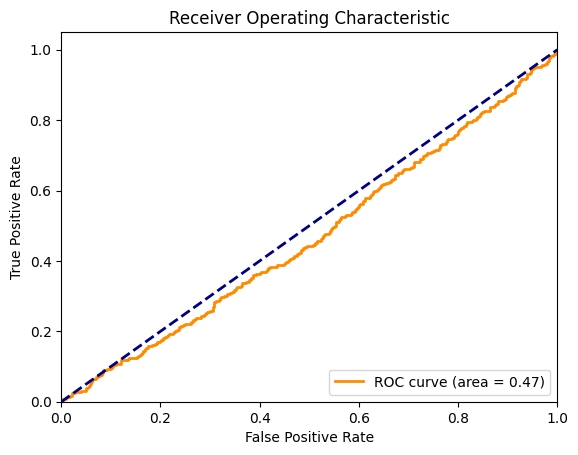

```
Training CNN-LSTM model
Epoch [10/50], Loss: 0.7206170558929443
Epoch [20/50], Loss: 0.7188452482223511
Epoch [30/50], Loss: 0.7167239785194397
Epoch [40/50], Loss: 0.7224602103233337
Epoch [50/50], Loss: 0.7131520509719849
Accuracy for CNN-LSTM model: 0.5082680591818973
```

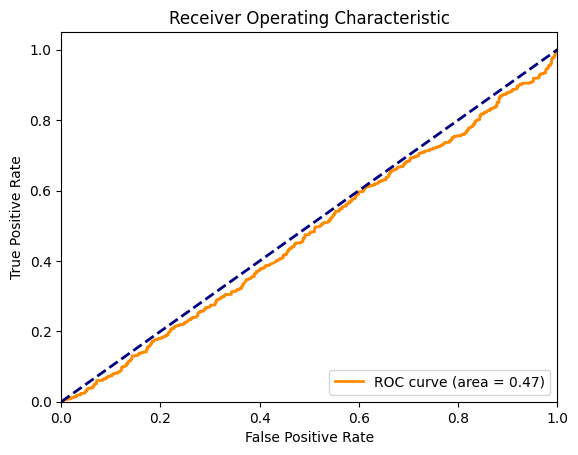

```python
import numpy as np
import torch
import torch.nn as nn
from sklearn.model_selection import train_test_split
from sklearn.metrics import accuracy_score, classification_report

# Set random seed for reproducibility
torch.manual_seed(42)

# Prepare the data
def create_dataset(data, look_back=1):
    X, y = [], []
    for i in range(len(data) - look_back):
        X.append(data[i:(i + look_back), 0])
        y.append(1 if data[i + look_back, 0] > data[i + look_back - 1, 0] else 0)
    return np.array(X), np.array(y)

# Define the GRU model
class GRUModel(nn.Module):
    def __init__(self, input_size, hidden_size, num_layers, output_size, dropout_rate=0.2):
        super(GRUModel, self).__init__()
        self.hidden_size = hidden_size
        self.num_layers = num_layers
        self.gru = nn.GRU(input_size, hidden_size, num_layers, batch_first=True, dropout=dropout_rate)
        self.dropout = nn.Dropout(dropout_rate)
        self.fc = nn.Linear(hidden_size, output_size)
        self.sigmoid = nn.Sigmoid()

    def forward(self, x):
        h0 = torch.zeros(self.num_layers, x.size(0), self.hidden_size).to(device)
        out, _ = self.gru(x, h0)
        out = self.dropout(out[:, -1, :])
        out = self.fc(out)
        out = self.sigmoid(out)
        return out

# Define the CNN-LSTM model
class CNNLSTMModel(nn.Module):
    def __init__(self, input_size, hidden_size, num_layers, output_size, dropout_rate=0.2):
        super(CNNLSTMModel, self).__init__()
        self.hidden_size = hidden_size
        self.num_layers = num_layers
        self.conv1 = nn.Conv1d(input_size, 64, kernel_size=3, padding=1)
        self.relu = nn.ReLU()
        self.lstm = nn.LSTM(64, hidden_size, num_layers, batch_first=True, dropout=dropout_rate)
        self.dropout = nn.Dropout(dropout_rate)
        self.fc = nn.Linear(hidden_size, output_size)
        self.sigmoid = nn.Sigmoid()

    def forward(self, x):
        x = x.permute(0, 2, 1)  # Reshape for CNN input
        x = self.conv1(x)
        x = self.relu(x)
        x = x.permute(0, 2, 1)  # Reshape for LSTM input
        h0 = torch.zeros(self.num_layers, x.size(0), self.hidden_size).to(device)
        c0 = torch.zeros(self.num_layers, x.size(0), self.hidden_size).to(device)
        out, _ = self.lstm(x, (h0, c0))
        out = self.dropout(out[:, -1, :])
        out = self.fc(out)
        out = self.sigmoid(out)
        return out

# Set device (GPU if available, else CPU)
device = torch.device('cuda' if torch.cuda.is_available() else 'cpu')

# Get a list of all the indices
indices = data['Index'].unique()

# Set the look_back value and other model parameters
look_back = 50
input_size = 1
hidden_size = 50
num_layers = 1
output_size = 1
num_epochs = 50
batch_size = 32
learning_rate = 0.001
dropout_rate = 0.2
l2_regularization = 0.001

# Loop through all the indices
for index in indices:
    print(f"Training models for index: {index}")

    # Extract the corresponding data
    data_index = data[data['Index'] == index]['Open'].values.reshape(-1, 1)

    # Create the dataset
    X, y = create_dataset(data_index, look_back)

    # Split the data into training and testing sets
    X_train, X_test, y_train, y_test = train_test_split(X, y, test_size=0.2, random_state=42)

    # Convert data to PyTorch tensors
    X_train = torch.tensor(X_train, dtype=torch.float32).to(device)
    y_train = torch.tensor(y_train, dtype=torch.float32).to(device)
    X_test = torch.tensor(X_test, dtype=torch.float32).to(device)
    y_test = torch.tensor(y_test, dtype=torch.float32).to(device)

    # Reshape the input tensors to have dimensions (batch_size, sequence_length, input_size)
    X_train = X_train.reshape(X_train.shape[0], look_back, input_size)
    X_test = X_test.reshape(X_test.shape[0], look_back, input_size)

    # Experiment with different model architectures
    models = [
        ('GRU', GRUModel(input_size, hidden_size, num_layers, output_size, dropout_rate)),
        ('CNN-LSTM', CNNLSTMModel(input_size, hidden_size, num_layers, output_size, dropout_rate))
    ]

    for model_name, model in models:
        print(f"Training {model_name} model")
        model = model.to(device)

        # Define the loss function and optimizer
        criterion = nn.BCELoss()
        optimizer = torch.optim.Adam(model.parameters(), lr=learning_rate, weight_decay=l2_regularization)

        roc_auc_funcs = []

        # Train the model
        for epoch in range(num_epochs):
            # Forward pass
            outputs = model(X_train)
            loss = criterion(outputs, y_train.view(-1, 1))

            # Add L2 regularization to the loss
            l2_reg = torch.tensor(0.).to(device)
            for param in model.parameters():
                l2_reg += torch.norm(param)
            loss += l2_regularization * l2_reg

            # Backward pass and optimization
            optimizer.zero_grad()
            loss.backward()
            optimizer.step()

            if (epoch + 1) % 10 == 0:
                print(f"Epoch [{epoch + 1}/{num_epochs}], Loss: {loss.item()}")

        # Make predictions on the test set
        with torch.no_grad():
            y_pred = model(X_test)
            y_pred_class = (y_pred > 0.5).float()

        # Calculate the accuracy and classification report
        accuracy = accuracy_score(y_test.cpu().numpy(), y_pred_class.cpu().numpy())
        report = classification_report(y_test.cpu().numpy(), y_pred_class.cpu().numpy())

        from sklearn.metrics import roc_curve, auc
        fpr, tpr, _ = roc_curve(y_test.cpu().numpy(), y_pred.cpu().numpy())
        roc_auc = auc(fpr, tpr)

        roc_auc_funcs.append(roc_auc)

        print(f"Accuracy for {model_name} model: {accuracy}\n")

        from sklearn.metrics import roc_curve, auc
        fpr, tpr, _ = roc_curve(y_test.cpu().numpy(), y_pred.cpu().numpy())
        roc_auc = auc(fpr, tpr)

        plt.figure()
        lw = 2
        plt.plot(fpr, tpr, color='darkorange', lw=lw, label='ROC curve (area = %0.2f)' % roc_auc)
        plt.plot([0, 1], [0, 1], color='navy', lw=lw, linestyle='--')
        plt.xlim([0.0, 1.0])
        plt.ylim([0.0, 1.05])
        plt.xlabel('False Positive Rate')
        plt.ylabel('True Positive Rate')
        plt.title('Receiver Operating Characteristic')
        plt.legend(loc="lower right")
        plt.show()

    break
```

These models seem equally ineffective. Then since every model so far had pretty bad accuracy we can try again with the differenced data since if the differenced data is greater than the previous value, then it is boolean true for growth and vice versa.

```
Training models for index: 000001.SS
Training LSTM model
Epoch [10/50], Loss: 0.6244654059410095
Epoch [20/50], Loss: 0.6125921010971069
Epoch [30/50], Loss: 0.6026308536529541
Epoch [40/50], Loss: 0.5958326458930969
Epoch [50/50], Loss: 0.5904941558837891
Accuracy for LSTM model: 0.710801393728223
```

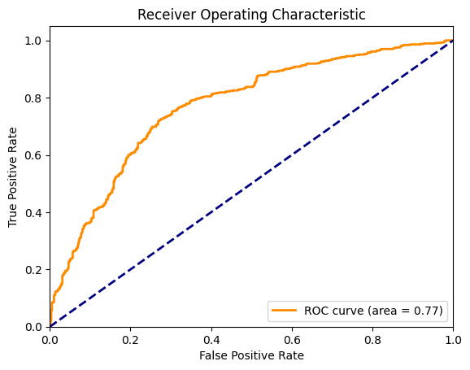

```
Training GRU model
Epoch [10/50], Loss: 0.6858813762664795
Epoch [20/50], Loss: 0.6621477007865906
Epoch [30/50], Loss: 0.6483635902404785
Epoch [40/50], Loss: 0.6312797665596008
Epoch [50/50], Loss: 0.6103327870368958
Accuracy for GRU model: 0.7020905923344948
```

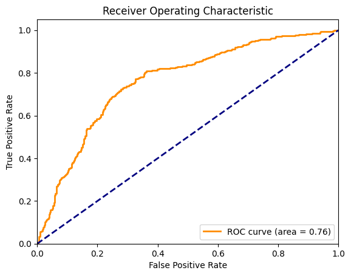

```
Training CNN-LSTM model
Epoch [10/50], Loss: 0.6424742937088013
Epoch [20/50], Loss: 0.6108144521713257
Epoch [30/50], Loss: 0.6007885336875916
Epoch [40/50], Loss: 0.5930423736572266
Epoch [50/50], Loss: 0.5854774117469788
Accuracy for CNN-LSTM model: 0.7168989547038328
```

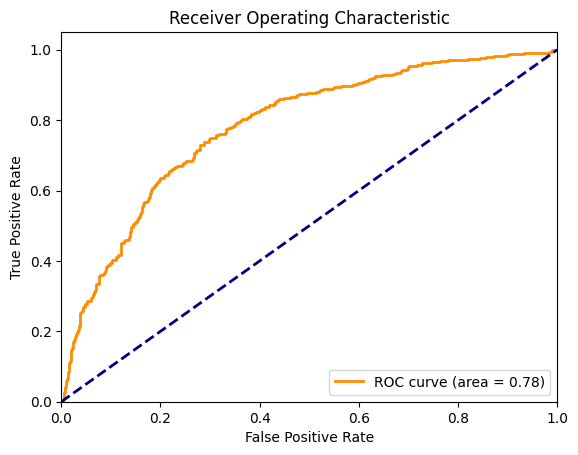

```python
import numpy as np
import torch
import torch.nn as nn
from sklearn.model_selection import train_test_split
from sklearn.metrics import accuracy_score, classification_report

# Set random seed for reproducibility
torch.manual_seed(42)

# Prepare the data
def create_dataset(data, look_back=1):
    X, y = [], []
    for i in range(len(data) - look_back):
        X.append(data[i:(i + look_back), 0])
        y.append(1 if data[i + look_back, 0] > data[i + look_back - 1, 0] else 0)
    return np.array(X), np.array(y)

# Define the GRU model
class GRUModel(nn.Module):
    def __init__(self, input_size, hidden_size, num_layers, output_size, dropout_rate=0.2):
        super(GRUModel, self).__init__()
        self.hidden_size = hidden_size
        self.num_layers = num_layers
        self.gru = nn.GRU(input_size, hidden_size, num_layers, batch_first=True, dropout=dropout_rate)
        self.dropout = nn.Dropout(dropout_rate)
        self.fc = nn.Linear(hidden_size, output_size)
        self.sigmoid = nn.Sigmoid()

    def forward(self, x):
        h0 = torch.zeros(self.num_layers, x.size(0), self.hidden_size).to(device)
        out, _ = self.gru(x, h0)
        out = self.dropout(out[:, -1, :])
        out = self.fc(out)
        out = self.sigmoid(out)
        return out

# Define the CNN-LSTM model
class CNNLSTMModel(nn.Module):
    def __init__(self, input_size, hidden_size, num_layers, output_size, dropout_rate=0.2):
        super(CNNLSTMModel, self).__init__()
        self.hidden_size = hidden_size
        self.num_layers = num_layers
        self.conv1 = nn.Conv1d(input_size, 64, kernel_size=3, padding=1)
        self.relu = nn.ReLU()
        self.lstm = nn.LSTM(64, hidden_size, num_layers, batch_first=True, dropout=dropout_rate)
        self.dropout = nn.Dropout(dropout_rate)
        self.fc = nn.Linear(hidden_size, output_size)
        self.sigmoid = nn.Sigmoid()

    def forward(self, x):
        x = x.permute(0, 2, 1)  # Reshape for CNN input
        x = self.conv1(x)
        x = self.relu(x)
        x = x.permute(0, 2, 1)  # Reshape for LSTM input
        h0 = torch.zeros(self.num_layers, x.size(0), self.hidden_size).to(device)
        c0 = torch.zeros(self.num_layers, x.size(0), self.hidden_size).to(device)
        out, _ = self.lstm(x, (h0, c0))
        out = self.dropout(out[:, -1, :])
        out = self.fc(out)
        out = self.sigmoid(out)
        return out

# Set device (GPU if available, else CPU)
device = torch.device('cuda' if torch.cuda.is_available() else 'cpu')

# Get a list of all the indices
indices = data['Index'].unique()

# Set the look_back value and other model parameters
look_back = 50
input_size = 1
hidden_size = 50
num_layers = 1
output_size = 1
num_epochs = 50
batch_size = 32
learning_rate = 0.001
dropout_rate = 0.2
l2_regularization = 0.001

# Loop through all the indices
for index in indices:
    print(f"Training models for index: {index}")

    # Extract the corresponding data
    data_index = data[data['Index'] == index]['Difference'].dropna().values.reshape(-1, 1)

    # Create the dataset
    X, y = create_dataset(data_index, look_back)

    # Split the data into training and testing sets
    X_train, X_test, y_train, y_test = train_test_split(X, y, test_size=0.2, random_state=42)

    # Convert data to PyTorch tensors
    X_train = torch.tensor(X_train, dtype=torch.float32).to(device)
    y_train = torch.tensor(y_train, dtype=torch.float32).to(device)
    X_test = torch.tensor(X_test, dtype=torch.float32).to(device)
    y_test = torch.tensor(y_test, dtype=torch.float32).to(device)

    # Reshape the input tensors to have dimensions (batch_size, sequence_length, input_size)
    X_train = X_train.reshape(X_train.shape[0], look_back, input_size)
    X_test = X_test.reshape(X_test.shape[0], look_back, input_size)

    # Experiment with different model architectures
    models = [
        ('LSTM', LSTMModel(input_size, hidden_size, num_layers, output_size, dropout_rate)),
        ('GRU', GRUModel(input_size, hidden_size, num_layers, output_size, dropout_rate)),
        ('CNN-LSTM', CNNLSTMModel(input_size, hidden_size, num_layers, output_size, dropout_rate))
    ]

    for model_name, model in models:
        print(f"Training {model_name} model")
        model = model.to(device)

        # Define the loss function and optimizer
        criterion = nn.BCELoss()
        optimizer = torch.optim.Adam(model.parameters(), lr=learning_rate, weight_decay=l2_regularization)

        roc_auc_funcs = []

        # Train the model
        for epoch in range(num_epochs):
            # Forward pass
            outputs = model(X_train)
            loss = criterion(outputs, y_train.view(-1, 1))

            # Add L2 regularization to the loss
            l2_reg = torch.tensor(0.).to(device)
            for param in model.parameters():
                l2_reg += torch.norm(param)
            loss += l2_regularization * l2_reg

            # Backward pass and optimization
            optimizer.zero_grad()
            loss.backward()
            optimizer.step()

            if (epoch + 1) % 10 == 0:
                print(f"Epoch [{epoch + 1}/{num_epochs}], Loss: {loss.item()}")

        # Make predictions on the test set
        with torch.no_grad():
            y_pred = model(X_test)
            y_pred_class = (y_pred > 0.5).float()

        # Calculate the accuracy and classification report
        accuracy = accuracy_score(y_test.cpu().numpy(), y_pred_class.cpu().numpy())
        report = classification_report(y_test.cpu().numpy(), y_pred_class.cpu().numpy())

        from sklearn.metrics import roc_curve, auc
        fpr, tpr, _ = roc_curve(y_test.cpu().numpy(), y_pred.cpu().numpy())
        roc_auc = auc(fpr, tpr)

        roc_auc_funcs.append(roc_auc)

        print(f"Accuracy for {model_name} model: {accuracy}\n")

        from sklearn.metrics import roc_curve, auc
        fpr, tpr, _ = roc_curve(y_test.cpu().numpy(), y_pred.cpu().numpy())
        roc_auc = auc(fpr, tpr)

        plt.figure()
        lw = 2
        plt.plot(fpr, tpr, color='darkorange', lw=lw, label='ROC curve (area = %0.2f)' % roc_auc)
        plt.plot([0, 1], [0, 1], color='navy', lw=lw, linestyle='--')
        plt.xlim([0.0, 1.0])
        plt.ylim([0.0, 1.05])
        plt.xlabel('False Positive Rate')
        plt.ylabel('True Positive Rate')
        plt.title('Receiver Operating Characteristic')
        plt.legend(loc="lower right")
        plt.show()

    break
```

This model can now with > 70% accuracy help tell us whether the change in the value of the stock price from one time step to another will be greater than it was before (if the second derivative will be positive or negative). This can be super useful for investing in these indeces when you already know the previous first derivatives.

### Conclusions

#### Volatility

This test helped show the relationship between the volatility of one index on another and found that there was a significant difference in the volatility of some indices versus others. This means that if you want a stable index so you don't lose too much money you would go for the stock that has the lowest mean with a significant difference from the other indices.

#### Change

This test helped show the relationship between the change of one index on another and found that there was a significant difference in the change of some indices versus others. This means that if you want an index that grows a lot you would go for the stock that has the highest mean with a significant difference from the other indices.

#### Autocorrelation

This test helped show how predictable an index was based on its previous values. If the index had a slow rate of decay across its ACF then the index was pretty predictable across its previous values. This means that if you want a predictable index you would go for the index that has the lowest rate of decay.

#### Cointegration

This test helped show how predictable an index was based on how another index is performing and its values. If the cointegration correlation coefficient was relatively high then the two stocks being compared had very similar patterns across the time they are moving often immitating each other. This means if you want to find what one index is doing you can look at another index with a high correlation.

#### Machine Learning

The developed model demonstrated promising performance, achieving an accuracy exceeding 70% in predicting whether the change in stock price from one time step to another will be greater than the previous change. In mathematical terms, the model effectively predicts the sign of the second derivative of the stock price time series.

This predictive capability has significant implications for investment strategies involving these stock market indices. By accurately forecasting whether the rate of change in stock prices will accelerate or decelerate, investors can make more informed decisions regarding the timing of their investments. If the model predicts a positive second derivative, it suggests that the stock price is likely to increase at a faster rate, potentially indicating a favorable time to invest. Conversely, a predicted negative second derivative implies a slowing down of the price increase or even a potential price decrease, which may signal a need for caution or a reevaluation of investment strategies.